# Determinants of Voting Behaviour in Recent Australian Elections

```r
# rename variables
names(survey_df) = c('year', 'id', 'interest_politics', 'interest_election_campaign', 'party_contact', 'contact_liberal',
              'contact_labour', 'contact_national', 'contact_greens', 'compulsory_vote', 'lower_vote_age',
              'online_political_group', 'political_affiliation', 'vote_reps', 'vote_senate', 'most_important_issue',
              'second_important_issue', 'personal_finances_12_months', 'economy_12_months', 'unions_powerful', 'banks_powerful',
              'death_penalty', 'marijuana_legal', 'harsher_penalties', 'women_preferential', 'turn_back_boats', 'euthanasia',
              'indigenous_constitution', 'first_priority', 'second_priority', 'immigrants_crime', 'immigrants_good_economy',
              'immigrants_take_jobs', 'global_warming', 'age_left_school', 'years_tertiary_study', 'qualification',
              'doing_last_week', 'occupation', 'who_work_for', 'belong_union', 'gender', 'year_birth', 'religion',
              'marital_status', 'own_home', 'investment_properties', 'self_managed_super', 'social_class','size_town',
              'annual_income', 'own_shares', 'state')

# some levels had too few resonses - collapse categories with < 100 responses
survey_df$interest_politics = fct_recode(survey_df$interest_politics,
                                         "Not much" = "None")
survey_df$interest_election_campaign = fct_recode(survey_df$interest_election_campaign,
                                                  "Not much" = "None")
survey_df$banks_powerful = fct_recode(survey_df$banks_powerful,
                                      "Disagree" = "Strongly disagree")
survey_df$harsher_penalties = fct_recode(survey_df$harsher_penalties,
                                         "Disagree" = "Strongly disagree")
survey_df$women_preferential = fct_recode(survey_df$women_preferential,
                                           "Agree" = "Strongly agree")
survey_df$euthanasia = fct_recode(survey_df$euthanasia,
                                  "Disagree" = "Strongly disagree")
survey_df$immigrants_good_economy = fct_recode(survey_df$immigrants_good_economy,
                                               'Disagree' = 'Strongly disagree')
survey_df$immigrants_take_jobs = fct_recode(survey_df$immigrants_take_jobs,
                                            'Agree' = 'Strongly agree')
survey_df$doing_last_week = fct_recode(survey_df$doing_last_week,
                                       "Other" = "Unemployed",
                                       "Other" = "Student",
                                       "Other" = "Carer")
survey_df$occupation = fct_recode(survey_df$occupation,
                                  "Other" = "Sales",
                                  "Other" = "Machinery Operator",
                                  "Other" = "Labourer")
survey_df$marital_status = fct_recode(survey_df$marital_status,
                                      "Other" = "Widowed",
                                      "Other" = "Divorced or separated")
survey_df$own_home = fct_recode(survey_df$own_home,
                                "Rent public" = "Other")
survey_df$social_class = fct_recode(survey_df$social_class,
                                    "Other" = "Upper",
                                    "Other" = "None")
survey_df$size_town = fct_recode(survey_df$size_town,
                                 "Country town" = "Small country town",
                                 "Country town" = "Large country town")
survey_df$lower_vote_age = fct_recode(survey_df$lower_vote_age,
                                      "Probably lower to 16" = "Definitely lower to 16")
survey_df$economy_12_months = fct_recode(survey_df$economy_12_months,
                                         "Better" = "A lot better",
                                         "Better" = "A little better")
survey_df$personal_finances_12_months = fct_recode(survey_df$personal_finances_12_months,
                                                   "Better" = "A lot better",
                                                   "Better" = "A little better")
survey_df$political_affiliation = fct_recode(survey_df$political_affiliation,
                                             "Other" = "National")
survey_df$vote_senate = fct_recode(survey_df$vote_senate,
                                   "Other" = "National")
survey_df$who_work_for = fct_recode(survey_df$who_work_for,
                                    "Company" = "Family business")
survey_df$most_important_issue = fct_recode(survey_df$most_important_issue,
                                            "Immigration and refugees" = "Immigration",
                                            "Immigration and refugees" = "Refugees and asylum seekers",
                                            "The economy" = "Government debt",
                                            "The economy" = "Managing the economy")
survey_df$second_important_issue = fct_recode(survey_df$second_important_issue,
                                            "Immigration and refugees" = "Immigration",
                                            "Immigration and refugees" = "Refugees and asylum seekers",
                                            "The economy" = "Government debt",
                                            "The economy" = "Managing the economy")
survey_df$state = fct_recode(survey_df$state,
                             "Other" = 'NT',
                             "Other" = 'ACT',
                             "Other" = "Tas")
survey_df$religion = fct_recode(survey_df$religion,
                                "Other" = "No religion",
                                "Other Christian" = "Uniting",
                                "Other Christian" = "Presbyterian")
survey_df = droplevels(survey_df)

# create variable whether voted lnp or not (the outcome)
survey_df$vote_lnp = fct_recode(survey_df$vote_reps,
                                'Yes' = 'Liberal',
                                'Yes' = 'National',
                                'No' = 'Labour',
                                'No' = 'Greens',
                                'No' = 'Other')
survey_df$vote_lnp = relevel(survey_df$vote_lnp, 'No') # make LNP the level we will predict
```

```r
# calculate age
year = as.numeric(as.character(survey_df$year))
survey_df$age = year - survey_df$year_birth

# drop only political group - only 24 yes, vote_senate, drop some other unused variables also
survey_df = dplyr::select(survey_df, -c(online_political_group, political_affiliation, vote_senate, party_contact, contact_liberal, contact_labour, contact_national, contact_greens, year_birth))

survey_df = droplevels(survey_df) # drop unused levels

# create some summaries of variables
# number of voters who voted lnp, total and number of na for this variable
n_lnp = survey_df %>% filter(vote_lnp=='Yes') %>% count()
n_total = survey_df %>% count()
n_lnp_na = survey_df %>% filter(is.na(vote_lnp)) %>% count()

# drop vote_reps - don't need anymore
survey_df = survey_df %>%  select(vote_lnp, everything(), -vote_reps)

# summary of dataframe variables
df_summary = skim(survey_df)
df_summary = df_summary[, c(2,1,5,6,3)]
names(df_summary) = c('Name', 'Type', 'Ordered', 'Unique', 'Missing')

# number of factors, numeric, ordered factors
n_factor = df_summary %>% filter(Type=='factor') %>% count()
n_num = ncol(survey_df) - n_factor
n_ordered = df_summary %>%  filter(Type=='factor' & Ordered==TRUE) %>% count()
max_levels = max(df_summary$Unique)
min_levels = min(df_summary$Unique)
n_id = n_distinct(survey_df$id)
```

The AES was a nationally representative longitudinal survey of Australian voters in the 2016 and 2019 federal elections (McAllister et al. 2019). The data set is available online in both long and wide formats (McAllister et al. 2019). This analysis used the long format data set, which has a column for year, rather than a 2016 and 2019 variable for each question in the survey.

A new variable `vote_lnp` was created that was “Yes” if the voter voted for the Liberal or National Party in the House of Representatives, otherwise “No”. This variable served as the outcome for the analysis. A total of 697 respondents voted LNP out of the the 1628 rows in the data set. Table 1 shows each of the factor variables selected for the analysis, showing the variable name, number of missing observations, whether the factor was ordered, and the number of levels. Table 2 displays information on numeric variables showing the variable name, number missing, and distributional information. Categorical variables with less than 100 responses in a given category were grouped together with other categories. There were 25 variables for which some categories were grouped together in this way. For ordinal variables, infrequent levels were grouped with the closest category (e.g., for the variable `euthanasia` “strongly disagree” was grouped with “disagree”). For nominal variables, categories with fewer than 100 responses were grouped together as “Other”.

```r
# summary table of factor variables
summary_factor = survey_df %>%
  skim() %>%
  filter(skim_type == 'factor') %>%
  select(skim_variable, n_missing, factor.ordered, factor.n_unique)
names(summary_factor) = c("Variable", "Missing (n)", "Ordered", "Levels (n)")

# table 1
kable(summary_factor, digits = 2, caption = "Table 1. Summary of factor variables showing the name, number of missing values, whether it is ordered, and number of levels.")
```

Table 1. Summary of factor variables showing the name, number of missing values, whether it is ordered, and number of levels.

| Variable | Missing (n) | Ordered | Levels (n) |
| --- | --- | --- | --- |
| vote_lnp | 29 | FALSE | 2 |
| year | 0 | FALSE | 2 |
| interest_politics | 4 | TRUE | 3 |
| interest_election_campaign | 8 | TRUE | 3 |
| compulsory_vote | 4 | TRUE | 4 |
| lower_vote_age | 5 | TRUE | 3 |
| most_important_issue | 58 | FALSE | 8 |
| second_important_issue | 99 | FALSE | 8 |
| personal_finances_12_months | 7 | TRUE | 4 |
| economy_12_months | 27 | TRUE | 4 |
| unions_powerful | 13 | TRUE | 5 |
| banks_powerful | 11 | TRUE | 4 |
| death_penalty | 10 | TRUE | 5 |
| marijuana_legal | 13 | TRUE | 5 |
| harsher_penalties | 9 | TRUE | 4 |
| women_preferential | 14 | TRUE | 4 |
| turn_back_boats | 16 | TRUE | 5 |
| euthanasia | 12 | TRUE | 4 |
| indigenous_constitution | 25 | TRUE | 4 |
| first_priority | 24 | FALSE | 4 |
| second_priority | 62 | FALSE | 4 |
| immigrants_crime | 11 | TRUE | 5 |
| immigrants_good_economy | 13 | TRUE | 4 |
| immigrants_take_jobs | 14 | TRUE | 4 |
| global_warming | 11 | TRUE | 4 |
| qualification | 37 | FALSE | 6 |
| doing_last_week | 35 | FALSE | 4 |
| occupation | 112 | FALSE | 6 |
| who_work_for | 130 | FALSE | 3 |
| belong_union | 66 | FALSE | 2 |
| gender | 15 | FALSE | 2 |
| religion | 49 | FALSE | 4 |
| marital_status | 19 | FALSE | 3 |
| own_home | 14 | FALSE | 4 |
| investment_properties | 13 | FALSE | 2 |
| self_managed_super | 15 | FALSE | 2 |
| social_class | 16 | FALSE | 3 |
| size_town | 19 | TRUE | 4 |
| annual_income | 66 | TRUE | 4 |
| own_shares | 20 | FALSE | 2 |
| state | 1 | FALSE | 6 |

```r
# summary table of numeric variables
summary_numeric = survey_df %>%
  select(-id) %>%
  skim() %>%
  filter(skim_type == 'numeric') %>%
  select(skim_variable, n_missing, numeric.mean, numeric.sd, numeric.p0, numeric.p100)
names(summary_numeric) = c('Variable', 'Missing (n)', 'Mean', 'SD', 'Minimum', 'Maximum')

# table 2
kable(summary_numeric, digits = 2, caption = "Table 2. Summary of numeric variables, showing the name, number missing, the mean, standard deviation (SD), minimum and maximum values.")
```

Table 2. Summary of numeric variables, showing the name, number missing, the mean, standard deviation (SD), minimum and maximum values.

| Variable | Missing (n) | Mean | SD | Minimum | Maximum |
| --- | --- | --- | --- | --- | --- |
| age_left_school | 54 | 16.96 | 3.56 | 12 | 98 |
| years_tertiary_study | 135 | 3.65 | 2.91 | 0 | 21 |
| age | 22 | 57.34 | 15.33 | 18 | 95 |

# Methods

The analysis was conducted in the `RStudio` programming environment using functions from base `R`, and the `tidyverse`, `mice`, `MASS`, `rms`, and `pROC` packages (R Core Team 2019; RStudio Team 2019; Wickham et al. 2019; van Buuren and Groothuis-Oudshoorn 2011; Venables and Ripley 2002; Harrell Jr 2019; Robin et al. 2011).

## Missing data

```r
# remove missing outcome - don't want to impute those
survey_df = survey_df[complete.cases(survey_df$vote_lnp) ,]

# proportion of missing data after missing vote_lnp removed
n_miss = colSums(is.na(survey_df))
# number and proportion of variable with most missing values
max_miss =  max(n_miss)
max_prop_miss = max(n_miss)/nrow(survey_df)

# variables with highest number of missing and values
n_years_tertiary_study_na = survey_df %>% filter(is.na(years_tertiary_study)) %>% count()
prop_years_tertiary_study_na = round(n_years_tertiary_study_na / nrow(survey_df), 2)

n_who_work_for_na = survey_df %>% filter(is.na(who_work_for)) %>% count()
prop_who_work_for_na = round(n_who_work_for_na / nrow(survey_df), 2)

n_occupation_na = survey_df %>% filter(is.na(occupation)) %>% count()
prop_occupation_na = round(n_occupation_na / nrow(survey_df), 2)

n_second_important_issue_na = survey_df %>% filter(is.na(second_important_issue)) %>% count()
n_year_na = survey_df %>% filter(is.na(year)) %>% count()

# impute missing
init = mice(survey_df, maxit=0)
meth = init$method
pred_mat = init$predictorMatrix

# don't use id and year to impute
pred_mat[,'id'] = 0
pred_mat[,'year'] = 0
meth['id'] = '' # none
meth['year']=''
meth['interest_politics'] = 'polr' #ordinal regression
meth['interest_election_campaign'] = 'polr'
meth['compulsory_vote'] = 'polr'
meth['lower_vote_age'] = 'polr'
meth['most_important_issue'] = 'polyreg' # multinomial logistic regression
meth['second_important_issue'] = 'polyreg'
meth['personal_finances_12_months'] = 'polr'
meth['economy_12_months'] = 'polr'
meth['unions_powerful'] = 'polr'
meth['banks_powerful'] = 'polr'
meth['death_penalty'] = 'polr'
meth['marijuana_legal'] = 'polr'
meth['harsher_penalties'] = 'polr'
meth['women_preferential'] = 'polr'
meth['turn_back_boats'] = 'polr'
meth['euthanasia'] = 'polr'
meth['indigenous_constitution'] = 'polr'
meth['first_priority'] = 'polyreg'
meth['second_priority'] = 'polyreg'
meth['immigrants_crime'] = 'polr'
meth['immigrants_good_economy'] = 'polr'
meth['immigrants_take_jobs'] = 'polr'
meth['global_warming'] = 'polr'
meth['age_left_school'] = 'pmm' # predictive mean matching
meth['years_tertiary_study'] = 'pmm'
meth['qualification'] = 'polyreg'
meth['doing_last_week'] = 'polyreg'
meth['occupation'] = 'polyreg'
meth['who_work_for'] = 'polyreg'
meth['belong_union'] = 'logreg'
meth['gender'] = 'logreg'
meth['religion'] = 'polyreg'
meth['marital_status'] = 'polyreg'
meth['own_home'] = 'polyreg'
meth['investment_properties'] = 'logreg'
meth['self_managed_super'] = 'logreg'
meth['social_class'] = 'polyreg'
meth['size_town'] = 'polr'
meth['annual_income'] = 'polr'
meth['own_shares'] = 'logreg'
meth['state'] = 'polyreg'
meth['age'] = 'pmm'

# impute missing values
imputed = mice(survey_df, m=1, method = meth, predictorMatrix = pred_mat, nnet.MaxNWts = 2000, printFlag = F)
imputed_df = complete(imputed)
```

## Training and validation samples

The imputed data set was split into a training and a validation sample using 70 percent for training and 30 percent for validation using functions from the `dplyr` library (Wickham et al. 2019). The data set was first grouped by respondent `id`, and was split in such a way as that no `id`s in the training sample were included in the validation sample.

```r
# create train test variable with no overlapping observations (id) between groups
set.seed(42) # set the random seed so results are reproducible
groups = imputed_df %>%
  dplyr::select(id) %>%
  distinct(id) %>%
  rowwise() %>%
  mutate(group = sample(c('train', 'test'), 1, replace = TRUE, prob = c(0.7, 0.3)))

imputed_df = imputed_df %>%
  left_join(groups)

train = imputed_df %>%
  filter(group == 'train') %>%
  dplyr::select(-group)

test = imputed_df %>%
  filter(group == 'test') %>%
  dplyr::select(-group)

# will need id for robust standard errors
id = dplyr::select(train, id)
train = train %>% dplyr::select(-id) # training sample
test = test %>%  dplyr::select(-id) # validation sample
```

## Logistic regression modelling

```r
# logistic regression modelling
# set options for rms package
dd_train = datadist(train) # create data distribution for fitting
options(datadist='dd_train') # set the data distribution
options(contrasts = c('contr.treatment', 'contr.treatment')) # set how to create dummy variables

# label variables for presentation
label(train$vote_lnp) = "Voted LNP"
label(train$year) = "Year surveyed"
label(train$interest_politics) = "Interest in politics"
label(train$interest_election_campaign) = "Interest in election"
label(train$compulsory_vote) = "Compulsory vote"
label(train$lower_vote_age) = "Lower voting age"
label(train$most_important_issue) = "Most important issue"
label(train$second_important_issue) = "Second important issue"
label(train$personal_finances_12_months) = "Personal finances past year"
label(train$economy_12_months) = "Economy past year"
label(train$unions_powerful) = "Unions too powerful"
label(train$banks_powerful) = "Big business too powerful"
label(train$death_penalty) = "Death penalty"
label(train$marijuana_legal) = "Marijuana legal"
label(train$harsher_penalties) = "Harsher penalties for crime"
label(train$women_preferential) = "Women preferential treatment"
label(train$turn_back_boats) = "Turn back all boats"
label(train$euthanasia) = "Euthanasia"
label(train$indigenous_constitution) = "Indigenous constitution"
label(train$first_priority) = "First priority"
label(train$second_priority) = "Second priority"
label(train$immigrants_crime) = "Immigrants cause crime"
label(train$immigrants_good_economy) = "Immigrants good economy"
label(train$immigrants_take_jobs) = "Immigrants take jobs"
label(train$global_warming) = "Global warming important"
label(train$age_left_school) = "Age left school"
label(train$years_tertiary_study) = "Years of tertiary study"
label(train$qualification) = "Qualifications"
label(train$doing_last_week) = "Doing last week"
label(train$occupation) = "Occupation"
label(train$who_work_for) = "Who work for"
label(train$belong_union) = "Belong to union"
label(train$gender) = "Gender"
label(train$religion) = "Religion"
label(train$marital_status) = "Marital Status"
label(train$own_home) = "Own your home"
label(train$investment_properties) = "Have investment properties"
label(train$self_managed_super) = "Have self managed super fund"
label(train$social_class) = "Social class"
label(train$size_town) = "Size of town live in"
label(train$annual_income) = "Annual income"
label(train$own_shares) = "Own shares"
label(train$state) = "State"
label(train$age) = "Age"

# function to calculate evaluation metrics
model_metrics = function(model, data, sample){
    preds = predict(model, data, type='fitted')
    class = ifelse(preds >= 0.5, 1, 0)
  #  accuracy
  cm = table(class, data$vote_lnp)
  accuracy = sum(diag(cm)) / sum(cm)
  error = 1 - accuracy
  #  precision
  precision = cm[2, 2]/sum(cm[2, ])
  #  recall
  recall = cm[2, 2]/sum(cm[, 2])
  #  F1 score
  f1 = 2 * precision * recall/(precision + recall)
  # auc
  auroc = auc(roc(data$vote_lnp, preds, quiet = TRUE))
  results = c(accuracy, error, precision, recall, f1, auroc)
  metric = c('Accuracy', 'Error', 'Precision', 'Recall', 'F1 score', 'AUC')
  metrics = data.frame(metric, results)
  colnames(metrics) = c('Metric', sample)
  return(metrics)
}

# function to calculate metrics for train and test sets
evaluate_model = function(model, train_data, test_data){
  train_metrics = model_metrics(model, train_data, 'train')
  test_metrics = model_metrics(model, test_data, 'test')
  metrics = left_join(train_metrics, test_metrics)
}

# fit first model - all predictors
lr_full = lrm(vote_lnp ~., data = train, x=TRUE, y=TRUE)

# calculate gamma
gamma_full = (920.48 - 124) / 920.48

# apply shrinkage to minimise overfitting
# choose penalty using aic
penalty_full = pentrace(lr_full, penalty = seq(0.5, 10, by=0.1), which = 'aic.c')
lr_full_pen = update(lr_full, penalty=penalty_full$penalty)

# use robust standard errors to interpret important predictors because of observations are not independent
lr_full_rob = robcov(lr_full_pen, id$id)

# calculate aic
aic_full = AIC(lr_full_rob)

# background info model
lr_back = lrm(vote_lnp ~ year + interest_politics + age_left_school + years_tertiary_study + qualification + doing_last_week + occupation + who_work_for + belong_union + gender + religion + marital_status + own_home + investment_properties + self_managed_super + social_class + size_town + annual_income + own_shares + state + age, data = train, x=TRUE, y=TRUE)

# gamma
gamma_back = (301.34 - 47) / 301.34

# apply shrinkage
penalty_back = pentrace(lr_back, penalty = seq(0.5, 5, by=0.1))
lr_back_pen = update(lr_back, penalty=penalty_back$penalty)

# apply robust errors
lr_back_rob = robcov(lr_back_pen, id$id)

# calculate aic
aic_back = AIC(lr_back_rob)

# issues model
lr_issues = lrm(vote_lnp ~ year + interest_politics + interest_election_campaign + compulsory_vote + lower_vote_age + most_important_issue + second_important_issue  + personal_finances_12_months + economy_12_months + unions_powerful + banks_powerful + death_penalty + marijuana_legal + harsher_penalties + women_preferential + turn_back_boats + euthanasia + indigenous_constitution + first_priority + second_priority + immigrants_crime + immigrants_good_economy + immigrants_take_jobs + global_warming, data = train, x=TRUE, y=TRUE)

# gamma
gamma_issues = (852.40 - 80) / 852.40

# apply shrinkage
penalty_issues = pentrace(lr_issues, penalty = seq(0.5, 5, by=0.1))
lr_issues_pen = update(lr_issues, penalty=penalty_issues$penalty)

# apply robust errors
lr_issues_rob = robcov(lr_issues_pen, id$id)

# calculate aic
aic_issues = AIC(lr_issues_rob)

# model info for all models
# combine aics
Model = c('Full', 'Background', "Issues")
Gamma = c(gamma_full, gamma_back, gamma_issues)
Penalty = c(penalty_full$penalty, penalty_back$penalty, penalty_issues$penalty)
aics = rbind.data.frame(aic_full, aic_back, aic_issues)
names(aics) = 'AIC'

model_info = cbind.data.frame(Model, Gamma, Penalty, aics)

# model evaluation and interpretation - use issues model - lowest aic
metrics_issues = evaluate_model(lr_issues_rob, train, test)

# analysis of variance
anova_issues = anova(lr_issues_rob, vnames = 'labels')

# investigate important predictors in model
union_pred = Predict(lr_issues_rob, name='unions_powerful', fun=plogis)
first_issue_pred = Predict(lr_issues_rob, name='most_important_issue', fun=plogis)
bank_pred = Predict(lr_issues_rob, name='banks_powerful', fun=plogis)
econ_pred = Predict(lr_issues_rob, name='economy_12_months', fun=plogis)
boats_pred = Predict(lr_issues_rob, name='turn_back_boats', fun=plogis)
second_issue_pred = Predict(lr_issues_rob, name = 'second_important_issue', fun = plogis)

# plots of important predictors
union_plot = ggplot(union_pred, adj.subtitle = F)
first_issue_plot = ggplot(first_issue_pred, adj.subtitle = F)
bank_plot = ggplot(bank_pred, adj.subtitle = F)
econ_plot = ggplot(econ_pred, adj.subtitle = F)
boat_plot = ggplot(boats_pred, adj.subtitle = F)
second_issue_plot = ggplot(second_issue_pred, adj.subtitle = F)
```

Logistic regression was used to model the probability of voting LNP in the training sample using the `lrm` function from the `rms` package (Harrell Jr 2019). Factor variables were prepared for one-hot encoding for modelling by setting `options(contrasts = c('contr.treatment', 'contr.treatment'))` in base `R`. The shrinkage coefficient ($\gamma$) was used to estimate the degree that a model was over fitting on the training set:
$$\gamma = \frac{\text{model }\chi^2 - df}{\text{model }\chi^2},$$

where $\text{model }\chi^2$ is the statistical test for the model, and *df* the total degrees of freedom from all variables in the model (e.g., a factor variable with four levels *costs* three *df*). A penalty was applied to the model coefficients if $\gamma$ was less than 0.95, as this indicated that results on the validation sample would likely be more than 5 percent worse than on the training set (Harrell Jr 2015). The shrinkage penalty was chosen by optimising corrected Akaike’s information criterion (AIC) on the training sample (Hurvich and Tsai 1989; Harrell Jr 2015). AIC is a measure of model fit that penalises complexity (Harrell Jr 2015), and is useful for evaluating model fit with relatively small sample sizes. AIC was a useful criterion for model fit ror this analysis, since there were only 1127 observations from 571 participants in the training sample.

An assumption of logistic regression is that observations are independent, but this was not the case in the training sample, because respondents were surveyed in both the 2016 and 2019 elections. Violation of this assumption can result in biased standard errors and *p*-values. Therefore, the Huber-White robust standard errors method was used to account for this grouping in the data using the `robcov` function from the `rms` package (Huber 1967; White 1980; Harrell Jr 2019).

The data set had variables in two main categories, attitudes toward election issues, such as the economy and immigration, and background information such as age, occupation and religion. To evaluate the importance of information from these categories, three models were fit on the training sample. One model was fit using only the election issues variables, another using only the background information, and a third used all the variables (both issues and background). The `year` variable that the survey was completed was included in all models. The model with the lowest AIC on the training set was taken as the final model. This process also served as a variable reduction method, since variables from a category of questions were dropped if they did not contribute information to the model (Harrell Jr 2019).

## Model evaluation and interpretation

The final model was evaluated on the training and test samples using accuracy, error, precision, recall, F1 score and area under the receiver operating characteristic curve (AUC-ROC). AUC-ROC was calculated using the `auc` and `roc` functions from the `pROC` package (Robin et al. 2011).

# Results

## Model fitting

Information for the three fitted models, including $\gamma$, penalty, and AIC is provided in Table 3. The $\gamma$ was less than 0.95 for all three models, so a penalty was applied to each model to reduce over fitting. The penalty was chosen by optimising corrected AIC using the `pentrace` function in the `rms` package. The penalty for each model was applied using the `update` function and robust standard errors with the `robcov` function from the `rms` package (Harrell Jr 2019). The election issues model had the lowest AIC (884.87), and was therefore taken as the final model for further evaluation and interpretation.

## Model evaluation

```r
# model info (table 3)
kable(model_info, digits = 2, caption = "Table 3. Model information for the three fitted models, including the shrinkage coefficient $\\gamma$  (gamma), penalty used and Akaike's information criterion (AIC).")
```

Table 3. Model information for the three fitted models, including the shrinkage coefficient $\gamma$ (gamma), penalty used and Akaike’s information criterion (AIC).

| Model | Gamma | Penalty | AIC |
| --- | --- | --- | --- |
| Full | 0.87 | 7.2 | 921.39 |
| Background | 0.84 | 5.0 | 1350.07 |
| Issues | 0.91 | 4.2 | 884.87 |

```r
# model metrics (table 4)
names(metrics_issues) = c("Metric", "Train", "Validation")
kable(metrics_issues, digits = 2, caption = "Table 4. Performance metrics for the election issues model on the training and validation samples.")
```

Table 4. Performance metrics for the election issues model on the training and validation samples.

| Metric | Train | Validation |
| --- | --- | --- |
| Accuracy | 0.87 | 0.82 |
| Error | 0.13 | 0.18 |
| Precision | 0.86 | 0.76 |
| Recall | 0.86 | 0.83 |
| F1 score | 0.86 | 0.80 |
| AUC | 0.94 | 0.90 |

## Model interpretation

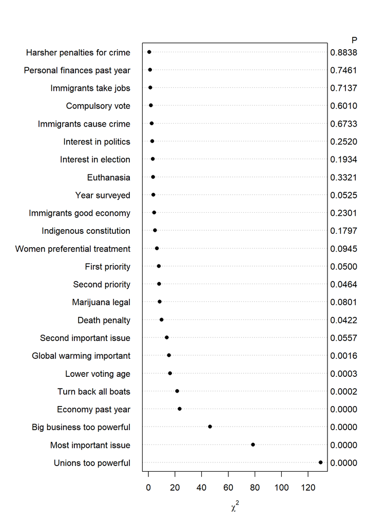

Figure 1. Importance of predictors in the election issues model in terms of amount of $\chi^2$ that a variable contributed to the model (*x*-axis), *p*-values for each variable are shown on the right.

```r
# Figure 1: importance of predictors in issues model
plot(anova_issues, what='chisq', margin = 'P')
```

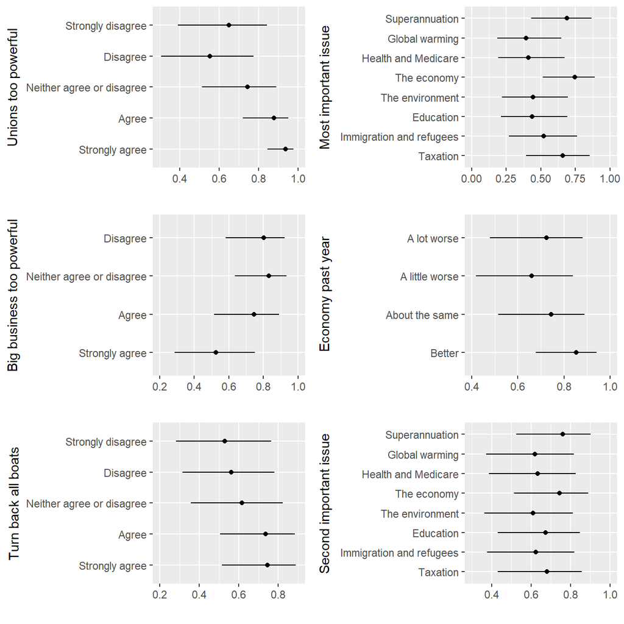

```r
# figure 2: the six most important predictors
plot_grid(union_plot, first_issue_plot, bank_plot, econ_plot, boat_plot, second_issue_plot, nrow = 3, align = 'hv')
```

# Discussion

```r
# year was not significant - how many voters changed their vote between 2016 and 2019?
# put in wide form
imputed_wide = imputed_df %>% pivot_wider(id_cols = id, names_from = year, values_from = vote_lnp)
change_vote = imputed_wide %>% filter(`2016` != `2019`)
```

The election issues model indicated that the issues of union power, management of the economy, boat turn-backs and superannuation played a central role in the outcomes of the 2016 and 2019 elections. The issues model was better fitting (lower AIC) than both the full model (all variables), and the background variables model, indicating that knowing where a voter stands on election issues is more informative than knowing their background and demographic information. Furthermore, including background details did not contribute substantial information once attitudes toward election issues were known. This indicates that knowing voters attitudes toward election issues is more important than background or demographic information when predicting voting behaviour.

An important limitation to this study is that it is not designed to predict future LNP voting behaviour. Whilst the model provided insights into the 2016 and 2019 elections, issues that are important to voters will change over time, and the relative importance may change over time, even for long standing issues such as the economy.

# Conclusion

This analysis mined the AES survey data set for insights into determinants of LNP voting behaviour in the House of Representatives the 2016 and 2019 federal elections. The election issues model was better fitting than both the background information model and the model using all variables, indicating that voter attitudes toward issues was more informative than background information, and adding background information did not contribute additional information once attitudes toward issues was known. The election issues model had excellent performance on the training sample that generalised well to the validation sample, and gave insight into important issues for LNP voters. LNP voters were more likely agree that unions were too powerful, list the economy and superannuation as important issues, disagree that big business was too powerful, think that the economy had improved in the previous year, and agree that all refugee asylum boats should be turned back.

# Reference List

Harrell Jr, Frank E. 2015. *Regression Modeling Strategies: With Applications to Linear Models, Logistic and Ordinal Regression, and Survival Analysis*. New York: Springer.

Harrell Jr, Frank E. 2019. *rms: Regression Modeling Strategies*. https://CRAN.R-project.org/package=rms.

Huber, Peter. 1967. “The Behavior of Maximum Likelihood Estimates Under Nonstandard Conditions.” *Proceedings of the Fifth Berkeley Symposium on Mathematical Statistics and Probability*, 59–82.

Hurvich, CM, and CL Tsai. 1989. “Regression and Time Series Model Selection in Small Samples.” *Biometrika* 76: 297–307.

James, Gareth, Daniela Witten, Trevor Hastie, and Robert Tibshirani. 2013. *An Introduction to Statistical Learning*. Vol. 112. New York: Springer.

McAllister, Ian, Clive Bean, Rachel Gibson, Toni Makkai, Jill Sheppard, and Sarah Cameron. 2019. “Australian Election Study, 2019.” ADA Dataverse. https://doi.org/10.26193/KMAMMW.

R Core Team. 2019. *R: A Language and Environment for Statistical Computing*. Vienna, Austria: R Foundation for Statistical Computing. https://www.R-project.org/.

Robin, Xavier, Natacha Turck, Alexandre Hainard, Natalia Tiberti, Frédérique Lisacek, Jean-Charles Sanchez, and Markus Müller. 2011. “pROC: An Open-Source Package for R and S+ to Analyze and Compare Roc Curves.” *BMC Bioinformatics* 12: 77.

RStudio Team. 2019. *RStudio: Integrated Development Environment for R*. Boston, MA: RStudio, Inc. http://www.rstudio.com/.

Steyerberg, Ewout W. 2019. *Clinical Prediction Models*. New York: Springer.

van Buuren, Stef, and Karin Groothuis-Oudshoorn. 2011. “mice: Multivariate Imputation by Chained Equations in R.” *Journal of Statistical Software* 45 (3): 1–67. https://www.jstatsoft.org/v45/i03/.

Venables, W. N., and B. D. Ripley. 2002. *Modern Applied Statistics with S*. Fourth. New York: Springer. http://www.stats.ox.ac.uk/pub/MASS4.

White, Halbert. 1980. “A Heteroskedasticity-Consistent Covariance Matrix Estimator and a Direct Test for Heteroskedasticity.” *Econometrica* 48: 817–38.

Wickham, Hadley, Mara Averick, Jennifer Bryan, Winston Chang, Lucy D’Agostino McGowan, Romain François, Garrett Grolemund, et al. 2019. “Welcome to the tidyverse.” *Journal of Open Source Software* 4 (43): 1686. https://doi.org/10.21105/joss.01686.